# Predictive-Modelling-Using-Social-Profile-in-Online-P2P-Lending-Financial-Market-

Both of financial data and social data are crucial for loans prediction. So, in this project we analyzed the dynamics of loans based on both financial and social data.

## Understanding the Dataset

- the data consists of two main tyoes of features social and financial features.
- our data consisting of many kinds of data: discrete features, continous features, categorical features, date features, boolen features and key features.
- so we need to deal with these data.
- The label of the dataset is loan status the loan should be paid or not.

## EDA

**Introduction:**

- **data** dataset comprises of 113937 rows and 81 columns. and it consists of 61 numerical features and 3 boolen features, 9 categorical features, 4 columns for dates and 4 columns for keys.
- **Information of Dataset:** Using countplot and barh we could see how our categorical features spread and how much each class represent.
- **Univariate Analysis:** Plotted histogram to see the distribution of data for each column and found that few variables are normally distributed and some of them are skewed. However, we can't really say about that which variables needed to be studied. Since, variables required to sudy more that how they are related to each oyher.
- **Descriptive Statistics:** Using **describe()** we could understand the numerical features more and more but I couldn't put a lot here because there are many features in the data for more info you can find them in the repository
- **Correlation Plot of Numerical Variables:** We choose a subet of the features that we think they are important to see their correlation.

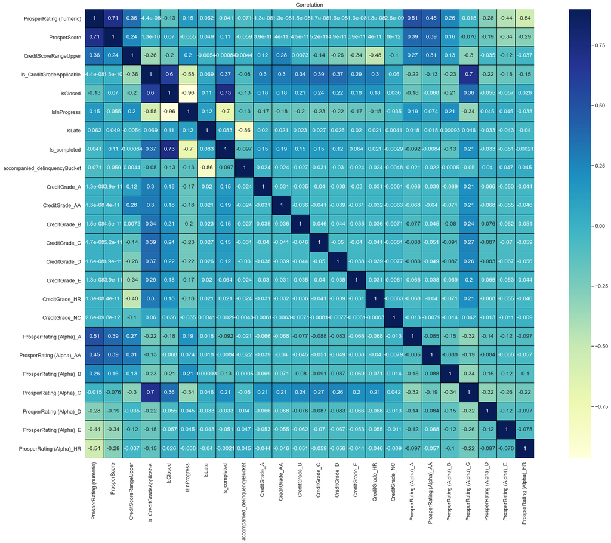

  as we can see here there are a few correlated features between the features that we created.
- **Visualisation of Variables:** we used alot of **pie plot** , **barh** and **distributions**
- **Note you can find alot of EDA in a notebook on our repository**

## Feature Engineering

- Here we created almost **15 new feature** to explain the missing data that is actually doesn't exist some of these features discussed below:
- after_July2009: used to explain the missing data in EstimatedEffectiveYield, EstimatedLoss, EstimatedReturn, ProsperRating (numeric), ProsperRating (Alpha) and ProsperScore as these features are Applicable for loans originated after July 2009
- had_PriorLoans: used to explain the missing data in TotalProsperLoans, TotalProsperPaymentsBilled, OnTimeProsperPayments, ProsperPaymentsLessThanOneMonthLate, ProsperPaymentsOneMonthPlusLate, ProsperPrincipalBorrowed, ProsperPrincipalOutstanding and ScorexChangeAtTimeOfListing as these features doesn't exist if the borrower had no prior loans
- **NoTE: you can find more in our notebook**

## Model Building

#### Metrics considered for Model Evaluation

**ROC, AUC score, Accuracy , Precision , Recall and F1 Score**

- ROC: it's a graph that provides a simple way to summaries all of the information its a plot betwwen False positve rate and true positive rate.
- AUC: it's the area under the roc curve.
- Accuracy: What proportion of actual positives and negatives is correctly classified?
- Precision: What proportion of predicted positives are truly positive ?
- Recall: What proportion of actual positives is correctly classified ?
- F1 Score : Harmonic mean of Precision and Recall.

#### Logistic Regression

- Logistic Regression helps find how probabilities are changed with actions.
- The function is defined as P(y) = 1 / 1+e^-(A+Bx)
- Logistic regression involves finding the **best fit S-curve** where A is the intercept and B is the regression coefficient. The output of logistic regression is a probability score.
- Used to predict if the loan should be paid or not

#### Neural Networks

- NN is a Machine Learning model inspired by the networks of biological neurons found in our brains.
- NNs are at the very core of Deep Learning. They are versatile, powerful, and scalable, making them ideal to tackle large and highly complex Machine Learning tasks, such as classifying billions of images.
- Used to see how the risk is if, we accepepted the loan

#### Naive Bayes

- Naive Bayes methods are a set of supervised learning algorithms based on applying Bayes’ theorem with the “naive” assumption of conditional independence between every pair of features given the value of the class variable. https://scikit-learn.org/stable/modules/naive_bayes.html?highlight=naive+bayes
- Again used to predict if the loan should be paid or not

#### Decision Tree Classifier

- Decision Trees (DTs) are a non-parametric supervised learning method used for classification and regression. The goal is to create a model that predicts the value of a target variable by learning simple decision rules inferred from the data features. A tree can be seen as a piecewise constant approximation.
- Again used to see how the risk is, if we accepepted the loan

### ROI

- Return on investment (ROI) is a performance measure used to evaluate the efficiency or profitability of an investment or compare the efficiency of a number of different investments. ROI tries to directly measure the amount of return on a particular investment, relative to the investment’s cost.
- we used the following formula: **ROI = (Gain - Cost of Investment) / Cost of Investment**

### Features used

##### All the features that is used for the final model:

- LP_CustomerPrincipalPayments: Pre charge-off cumulative principal payments made by the borrower on the loan. If the loan has charged off, this value will exclude any recoveries.
- LoanCurrentDaysDelinquent: The number of days delinquent.
- LoanMonthsSinceOrigination: Number of months since the loan originated.
- LP_ServiceFees: Cumulative service fees paid by the investors who have invested in the loan.
- MonthlyLoanPayment: The scheduled monthly loan payment.
- LoanOriginalAmount: The origination amount of the loan.
- BorrowerAPR: The Borrower's Annual Percentage Rate (APR) for the loan.
- EstimatedEffectiveYield:
- after_July2009: for loans originated after July 2009 the value will be **1**, otherwise **0**
- CreditGrade_Not_Applicable: Applicable for listings pre-2009 period and will only be populated for those listings. If applicable the value will be **1** otherwise **0**
- Term: The length of the loan expressed in months.
- Investors: The number of investors that funded the loan.
- Occupation_Professional: The Occupation selected by the Borrower at the time they created the listing.If Professional the value will be **1** otherwise **0**
- Occupation_Retail Management: The Occupation selected by the Borrower at the time they created the listing.If Retail Management the value will be **1** otherwise **0**
- BorrowerState_NC: The two letter abbreviation of the state of the address of the borrower at the time the Listing was created. If NC the value will be **1** otherwise **0**
- AvailableBankcardCredit: The total available credit via bank card at the time the credit profile was pulled.
- Occupation_Sales - Retail: The Occupation selected by the Borrower at the time they created the listing.If Sales - Retail the value will be **1** otherwise **0**
- StatedMonthlyIncome: The monthly income the borrower stated at the time the listing was created.
- BorrowerState_OK: The two letter abbreviation of the state of the address of the borrower at the time the Listing was created. If OK the value will be **1** otherwise **0**
- Recommendations: Number of recommendations the borrower had at the time the listing was created.
- Interest Rate: The Borrower's interest rate for this loan.

## Deployment

- you can find our app through the repository link here : https://github.com/Technocolabs100/Predictive-Modelling-Using-Social-Profile-in-Online-P2P-Lending-Financial-Market-.git

### Flask

- We created our app by using flask.